# Workshop Mutation PSPG 245B

Lee and Martell

11 February, 2020

# PSPG 245B

In this workshop you will learn about the fundamentals of mutation identification in cancer. By the end of the course you should be able to generate your own full R markdown for your assigned TCGA ID, including plots and identification of actionable mutations. Please see the the accompanying PDF for more information.

## The following are required for this workshop

Software requirements

- R >3.5 and have the below packages installed.
- use BiocManager::install() when possible.
  - cgdsr
  - ggplot2
  - knitr
  - kableExtra
  - dplyr
  - VennDiagram
  - reshape2

Please make sure to either clone the github repo or download the entire dropbox folder. Unzip this to a folder.

- https://www.dropbox.com/sh/lvaqmurdozncnxw/AADWRtK8woO4MjXIvGqcUcpXa?dl=1
- https://github.com/ahdee/workshop.mutation.2019

In this workshop we will be mainly using cbioportal’s API to download the data we need. Thus it is important that you have access to the internet.

We will be using the TCGA study on Breast Invasive Carcinoma (TCGA, Cell 2015)

- Each student should had been assigned a TCGA ID prior to this.
  - TCGA-C8-A3M7-01
  - TCGA-GM-A2D9-01
  - TCGA-BH-A1FL-01
  - TCGA-E2-A14Z-01
  - TCGA-BH-A1FC-01
  - TCGA-AC-A2QJ-01
  - TCGA-EW-A1P8-01
  - TCGA-E2-A1LE-01
  - TCGA-E2-A1LK-01
  - TCGA-AC-A2FE-01

Important: please remember to set the working directory to your source by clicking Sesssion-> Set working directory -> to source file location

```r
# load require package and "source" an auxillary R script design for this workshop.
# the auxillary script will help manage some of the more complex/redundant tasks

library ( cgdsr)
library ( ggplot2)
library(knitr)
library(kableExtra)
library ( dplyr)
library ( reshape2)
library(VennDiagram)
source("auxi.R")

# initiate cbioportal API
cbiop = CGDS("http://www.cbioportal.org/")
```

# Lets learn how communicate with cbioportal and study what is available.

- This portal is hierarchically structured. This is the workflow will will use.
  - List of all the cancer studies available on this portal.
  - Identify the study you want
  - List all the “cases” for that study, a case is a description of both data available for the study and/or subsets of certain phenotypes
  - With each case you can get the list of all the associated TCGA identify
  - which you can then use to get all the clincal data assocaited with the TCGA samples.
  - moreover you use the study to get specific genetic profile ( datasets available for downloading ).
  - From here you can then download the actual data.

```r
# Start by getting a list of cancer studies available at cbio
studies = getCancerStudies(cbiop)

# This will return a table with a list of available cancer studies to draw from
k2( head ( studies, 10) , "example list of data available in cbioportal")
```

example list of data available in cbioportal

| cancer_study_id | name | description |
| --- | --- | --- |
| paac_jhu_2014 | Acinar Cell Carcinoma of the Pancreas (JHU, J Pathol 2014) | Whole exome sequencing of 23 surgically resected pancreatic carcinomas with acinar differentiation and their matched normals. |
| mel_tsam_liang_2017 | Acral Melanoma (TGEN, Genome Res 2017) | Whole exome sequencing and transcriptome analysis of 34 Acral Melanoma patients (33 with matched normals). |
| all_stjude_2015 | Acute Lymphoblastic Leukemia (St Jude, Nat Genet 2015) | Comprehensive profiling of infant MLL-rearranged acute lymphoblastic leukemia (MLL-R ALL) |
| all_stjude_2016 | Acute Lymphoblastic Leukemia (St Jude, Nat Genet 2016) | Whole-genome and/or whole-exome sequencing of ERG-altered B-ALL tumor/normal pairs. |
| aml_ohsu_2018 | Acute Myeloid Leukemia (OHSU, Nature 2018) | Whole-exome sequencing of 672 acute myeloid leukemia samples (with 454 matched normals) from the Beat AML program. |
| laml_tcga | Acute Myeloid Leukemia (TCGA, Firehose Legacy) | TCGA Acute Myeloid Leukemia; raw data at the <A HREF=“https://tcga-data.nci.nih.gov/”>NCI</A>; source mutation data from <a HREF=“http://gdac.broadinstitute.org/runs/stddata__2016_01_28/data/LAML/2016… |
| laml_tcga_pub | Acute Myeloid Leukemia (TCGA, NEJM 2013) | Whole-genome or whole-exome sequencing analysis of 200 adult de novo AML tumor/normal pairs. TCGA Acute Myeloid Leukemia Project; raw data at the <A HREF=“https://tcga-data.nci.nih.gov/tcga/tcgaCancer… |
| laml_tcga_pan_can_atlas_2018 | Acute Myeloid Leukemia (TCGA, PanCancer Atlas) | Acute Myeloid Leukemia TCGA PanCancer data. The original data is <a href=“https://gdc.cancer.gov/about-data/publications/pancanatlas”>here</a>. The publications are <a href=“https://www.cell.com/pb-as… |
| mnm_washu_2016 | Acute myeloid leukemia or myelodysplastic syndromes (WashU, 2016) | Enhanced exome or targeted sequencing of 116 acute myeloid leukemia (AML) or myelodysplastic syndromes (MDS) patients’ tumor/normal pairs . |
| acyc_fmi_2014 | Adenoid Cystic Carcinoma (FMI, Am J Surg Pathl. 2014) | Comprehensive genomic profiling of 28 metastatic ACCs. |

```r
# note: k2 is one of those cheat codes to make tables print out nicely
# ? what is the "10" for in the function above.

# lets find out how many studies are available to the public
dim ( studies ) # dim is a function to tabulate a dataframe
```

```
## [1] 277   3
```

```r
# ? how do you think we can use this to look for the dataset we need amoung > 200 studies?

# Find the dataset you want.
# According to the syllabus we are looking for TCGA study on Breast Invasive Carcinoma (TCGA, Cell 2015)
# However lets first search for all the breast cancer studies available so that we can look to see what is availabe.

breast = studies[ grepl("Breast", studies$name, ignore.case = T ), ]

# ? what is the T for what if you use lower case instead of upper case

k2(breast, "list of breast related studies")
```

list of breast related studies

|  | cancer_study_id | name | description |
| --- | --- | --- | --- |
| 17 | acbc_mskcc_2015 | Adenoid Cystic Carcinoma of the Breast (MSKCC, J Pathol. 2015) | Whole exome sequencing of 12 breast AdCCs. |
| 37 | brca_metabric | Breast Cancer (METABRIC, Nature 2012 & Nat Commun 2016) | Targeted sequencing of 2509 primary breast tumors with 548 matched normals. |
| 38 | breast_msk_2018 | Breast Cancer (MSK, Cancer Cell 2018) | Targeted Sequencing of tumor/normal sample pairs from 1918 Breast cancers. |
| 39 | brca_mskcc_2019 | Breast Cancer (MSKCC, 2019) | Targeted Sequencing of buparlisib + letrozole and alpelisib + letrozole-treated metastatic ER+ unmatched breast tumors. |
| 40 | brca_bccrc_xenograft_2014 | Breast Cancer Xenografts (British Columbia, Nature 2015) | Whole genome/targeted sequencing to evaluate the clonal dynamics in 116 breast cancer patient xenografts. |
| 41 | bfn_duke_nus_2015 | Breast Fibroepithelial Tumors (Duke-NUS, Nat Genet 2015) | Whole exome sequencing of 22 phyllodes tumors |
| 42 | brca_bccrc | Breast Invasive Carcinoma (British Columbia, Nature 2012) | Whole genome/exome sequencing analysis of 65 breast cancer samples |
| 43 | brca_broad | Breast Invasive Carcinoma (Broad, Nature 2012) | Whole-exome sequencing of 103 breast cancer tumor/normal sample pairs. Generated by the Broad Institute. |
| 44 | brca_sanger | Breast Invasive Carcinoma (Sanger, Nature 2012) | Whole exome sequencing from 100 breast cancer tumor/normal sample pairs. Generated by the Sanger Institute. |
| 45 | brca_tcga_pub2015 | Breast Invasive Carcinoma (TCGA, Cell 2015) | Whole-exome sequencing of 817 Breast Invasive Carcinoma tumor/normal pairs. The Cancer Genome Atlas (TCGA) Breast Invasive Carcinoma Project. |
| 46 | brca_tcga | Breast Invasive Carcinoma (TCGA, Firehose Legacy) | TCGA Breast Invasive Carcinoma; raw data at the <A HREF=“https://tcga-data.nci.nih.gov/”>NCI</A>; source mutation data from <a HREF=“http://gdac.broadinstitute.org/runs/stddata__2016_01_28/data/BRCA/2… |
| 47 | brca_tcga_pub | Breast Invasive Carcinoma (TCGA, Nature 2012) | Whole-exome sequencing (510 samples with matched normals), genomic DNA copy number arrays, DNA methylation, messenger RNA arrays, microRNA sequencing and reverse-phase protein arrays analysis on 825 p… |
| 48 | brca_tcga_pan_can_atlas_2018 | Breast Invasive Carcinoma (TCGA, PanCancer Atlas) | Breast Invasive Carcinoma TCGA PanCancer data. The original data is <a href=“https://gdc.cancer.gov/about-data/publications/pancanatlas”>here</a>. The publications are <a href=“https://www.cell.com/pb… |
| 152 | brca_igr_2015 | Metastatic Breast Cancer (INSERM, PLoS Med 2016) | Whole exome sequencing of 216 tumor/normal (blood) pairs from metastatic breast cancer patients who underwent a biopsy in the context of the SAFIR01/SAFIR02 (Unicancer, France), SHIVA (Institut Curie,… |
| 254 | brca_mbcproject_wagle_2017 | The Metastatic Breast Cancer Project (Provisional, October 2018) | Whole-exome sequencing of 237 metastatic breast cancer samples. The Metastatic Breast Cancer Project is a patient-driven initiative. This study includes genomic data, patient-reported data (pre-pended… |

```r
### First BONUS question! try to find if there are other cancer data you might interested in, eg Lung Cancer

# from the table we now know that the study id is:  brca_tcga_pub2015

brca.study = "brca_tcga_pub2015"

# note: each institution has different ways of organizing their data
# ok from the study we can identify all the available data by using a case list API


mycaselist = getCaseLists(cbiop,brca.study)


# notice that descriptions contains not only type of samples but sometimes it includes what type of data they are.

k2 ( head ( mycaselist[ ,c("case_list_id",   "case_list_name",   "case_list_description",    "cancer_study_id"  )], 50), "list of cases for the BRCA CELL 2015 study" )
```

list of cases for the BRCA CELL 2015 study

| case_list_id | case_list_name | case_list_description | cancer_study_id |
| --- | --- | --- | --- |
| brca_tcga_pub2015_all | All samples | All samples (817 samples) | 2119 |
| brca_tcga_pub2015_erpos | ER+ breast tumors | ER+ breast tumors (594 samples) | 2119 |
| brca_tcga_pub2015_erneg | ER- breast tumors | ER- breast tumors (174 samples) | 2119 |
| brca_tcga_pub2015_her2pos | Her2-positive breast tumors | Her2-positive breast tumors (120 samples) | 2119 |
| brca_tcga_pub2015_idc_luma | Invasive Ductal Cancer (Luminal A) | Invasive Ductal Luminal A Breast Tumors (201 samples) | 2119 |
| brca_tcga_pub2015_idc_basal | Invasive Ductal Cancer (PAM50 Basal-like) | PAM50 Basal-like subtype in IDC (107 samples) | 2119 |
| brca_tcga_pub2015_idc_her2 | Invasive Ductal Cancer (PAM50 Her2-enriched) | PAM50 Her2-enriched subtype in IDC (51 samples) | 2119 |
| brca_tcga_pub2015_idc_lumB | Invasive Ductal Cancer (PAM50 Luminal B) | PAM50 Luminal B subtype in IDC (122 samples) | 2119 |
| brca_tcga_pub2015_ilc | Invasive Lobular Cancer | Invasive Lobular Breast Tumors (127 samples) | 2119 |
| brca_tcga_pub2015_ilc_lumA | Invasive Lobular Cancer (Luminal A) | Invasive Lobular Luminal A Breast Tumors (106 samples) | 2119 |
| brca_tcga_pub2015_mixed | Mixed IDC/ILC breast cancer | Mixed ILC/IDC breast cancer (88 samples) | 2119 |
| brca_tcga_pub2015_other | Other histologies breast cancer | Other histologies of breast cancer (112 samples) | 2119 |
| brca_tcga_pub2015_cna | Samples with CNA data | Samples with CNA data (816 samples) | 2119 |
| brca_tcga_pub2015_methylation_all | Samples with methylation data | Samples with methylation data (817 samples) | 2119 |
| brca_tcga_pub2015_methylation_hm27 | Samples with methylation data (HM27) | Samples with methylation data (HM27) (264 samples) | 2119 |
| brca_tcga_pub2015_methylation_hm450 | Samples with methylation data (HM450) | Samples with methylation data (HM450) (553 samples) | 2119 |
| brca_tcga_pub2015_mrna | Samples with mRNA data (Agilent microarray) | Samples with mRNA expression data (421 samples) | 2119 |
| brca_tcga_pub2015_rna_seq_v2_mrna | Samples with mRNA data (RNA Seq V2) | Samples with mRNA expression data (817 samples) | 2119 |
| brca_tcga_pub2015_cnaseq | Samples with mutation and CNA data | Samples with mutation and CNA data (816 samples) | 2119 |
| brca_tcga_pub2015_sequenced | Samples with mutation data | Samples with mutation data (817 samples) | 2119 |
| brca_tcga_pub2015_rppa | Samples with protein data (RPPA) | Samples protein data (RPPA) (673 samples) | 2119 |
| brca_tcga_pub2015_freeze | TCGA Freeze 2015 | TCGA second data freeze (817 samples) | 2119 |
| brca_tcga_pub2015_trineg | Triple-negative breast tumors | Triple-negative breast tumors (82 samples) | 2119 |

```r
# ? Which data do you think is most relevant for this workshop?

# here we see that brca_tcga_pub2015_all is probably the best to use because it includes ALL Complete Tumors
# compared to brca_tcga_pub2015_her2pos which are only samples that are Her2-positive breast tumors
```

## For **reproducibility** we need to consider either the “freeze” case or store a local copy. This is an important point that is often overlook!

- Also be aware that cbio is only 1 of many different portals available to the public. It is not necessarily the best.

```r
case.list.id = "brca_tcga_pub2015_all"


# ok now using All Complete Tumors lets see if your sample is present.

# first lets get all the TCGA ID associated with this case
mysample = mycaselist[ mycaselist$case_list_id == case.list.id, ]$case_ids
mysample = unlist ( strsplit(mysample, " ") )

# ? mysample variable now contains all the TCGA samples in this study, can you check if your sample is exists?

# here is the list of samples we stored in the auxillary. Do you see your sample in here?

cat ( samples, sep="\n")
```

```
## TCGA-C8-A3M7-01
## TCGA-GM-A2D9-01
## TCGA-BH-A1FL-01
## TCGA-E2-A14Z-01
## TCGA-BH-A1FC-01
## TCGA-AC-A2QJ-01
## TCGA-EW-A1P8-01
## TCGA-E2-A1LE-01
## TCGA-E2-A1LK-01
## TCGA-AC-A2FE-01
```

## Here I chose a random sample to test

- IMPORTANT! here you need to use your own assigned TCGA ID

```r
myid = "TCGA-C8-A131-01"
mysample[mysample== myid]
```

```
## [1] "TCGA-C8-A131-01"
```

```r
# here is another way
intersect ( mysample, myid)
```

```
## [1] "TCGA-C8-A131-01"
```

```r
# yet another
mysample[grepl(myid, mysample)]
```

```
## [1] "TCGA-C8-A131-01"
```

```r
#? can you think of any reason to use grep over another?

### Now lets check if it matches with what is reported: 817
length ( mysample)
```

```
## [1] 817
```

## With this list of TCGA ids we can also get clinical data for each of the samples.

```r
# lets get clinical some data
myclinicaldata = getClinicalData(cbiop,getCaseLists(cbiop,brca.study)[1,1])
# clean up the names a bit
myclinicaldata$pid = gsub ( "\\.", "-", row.names(myclinicaldata))
# lets get the clinical information for your TCGA id.
k2 ( t ( myclinicaldata[myclinicaldata$pid %in% myid, ] ))
```

|  | TCGA.C8.A131.01 |
| --- | --- |
| AGE | 82 |
| AJCC_METASTASIS_PATHOLOGIC_PM | M0 |
| AJCC_NODES_PATHOLOGIC_PN | N2 |
| AJCC_PATHOLOGIC_TUMOR_STAGE | Stage IIIA |
| AJCC_STAGING_EDITION | 6th |
| AJCC_TUMOR_PATHOLOGIC_PT | T2 |
| BRACHYTHERAPY_TOTAL_DOSE_POINT_A |  |
| CANCER_TYPE | Invasive Breast Carcinoma |
| CANCER_TYPE_DETAILED | Breast Invasive Ductal Carcinoma |
| CENT17_COPY_NUMBER |  |
| DAYS_TO_BIRTH | -29966 |
| DAYS_TO_COLLECTION | 163 |
| DAYS_TO_DEATH | NA |
| DAYS_TO_INITIAL_PATHOLOGIC_DIAGNOSIS | 0 |
| DAYS_TO_LAST_FOLLOWUP | 14 |
| DFS_MONTHS | 13.5 |
| DFS_STATUS | DiseaseFree |
| DISEASE_CODE |  |
| ER_POSITIVITY_SCALE_OTHER |  |
| ER_POSITIVITY_SCALE_USED |  |
| ER_STATUS_BY_IHC | Negative |
| ER_STATUS_IHC_PERCENT_POSITIVE |  |
| ETHNICITY | NOT HISPANIC OR LATINO |
| FIRST_SURGICAL_PROCEDURE_OTHER | Patey’s Surgery |
| FORM_COMPLETION_DATE | 4/15/11 |
| FRACTION_GENOME_ALTERED | 0.2303 |
| HER2_AND_CENT17_CELLS_COUNT | NA |
| HER2_AND_CENT17_SCALE_OTHER |  |
| HER2_CENT17_RATIO | NA |
| HER2_COPY_NUMBER |  |

[output cut: 78 more lines]

```r
# important fields to consider.
# AGE, AJCC_PATHOLOGIC_TUMOR_STAGE, Ethnicity
# DFS ( disease free), OS ( overall survival)


### Bonus Lets have some fun here, even with just a table of clinical data we can do some investigation.
# For example how would you figure out if one of your sample ( the assigned TCGA) is a Triple-negative or HER2+.
# hint look at the caselist and work backwards using the intersect function

k2 ( head ( mycaselist[ ,c("case_list_id",   "case_list_name",   "case_list_description",    "cancer_study_id"  )], 50), "list of cases for the BRCA CELL 2015 study" )
```

list of cases for the BRCA CELL 2015 study

| case_list_id | case_list_name | case_list_description | cancer_study_id |
| --- | --- | --- | --- |
| brca_tcga_pub2015_all | All samples | All samples (817 samples) | 2119 |
| brca_tcga_pub2015_erpos | ER+ breast tumors | ER+ breast tumors (594 samples) | 2119 |
| brca_tcga_pub2015_erneg | ER- breast tumors | ER- breast tumors (174 samples) | 2119 |
| brca_tcga_pub2015_her2pos | Her2-positive breast tumors | Her2-positive breast tumors (120 samples) | 2119 |
| brca_tcga_pub2015_idc_luma | Invasive Ductal Cancer (Luminal A) | Invasive Ductal Luminal A Breast Tumors (201 samples) | 2119 |
| brca_tcga_pub2015_idc_basal | Invasive Ductal Cancer (PAM50 Basal-like) | PAM50 Basal-like subtype in IDC (107 samples) | 2119 |
| brca_tcga_pub2015_idc_her2 | Invasive Ductal Cancer (PAM50 Her2-enriched) | PAM50 Her2-enriched subtype in IDC (51 samples) | 2119 |
| brca_tcga_pub2015_idc_lumB | Invasive Ductal Cancer (PAM50 Luminal B) | PAM50 Luminal B subtype in IDC (122 samples) | 2119 |
| brca_tcga_pub2015_ilc | Invasive Lobular Cancer | Invasive Lobular Breast Tumors (127 samples) | 2119 |
| brca_tcga_pub2015_ilc_lumA | Invasive Lobular Cancer (Luminal A) | Invasive Lobular Luminal A Breast Tumors (106 samples) | 2119 |
| brca_tcga_pub2015_mixed | Mixed IDC/ILC breast cancer | Mixed ILC/IDC breast cancer (88 samples) | 2119 |
| brca_tcga_pub2015_other | Other histologies breast cancer | Other histologies of breast cancer (112 samples) | 2119 |
| brca_tcga_pub2015_cna | Samples with CNA data | Samples with CNA data (816 samples) | 2119 |
| brca_tcga_pub2015_methylation_all | Samples with methylation data | Samples with methylation data (817 samples) | 2119 |
| brca_tcga_pub2015_methylation_hm27 | Samples with methylation data (HM27) | Samples with methylation data (HM27) (264 samples) | 2119 |
| brca_tcga_pub2015_methylation_hm450 | Samples with methylation data (HM450) | Samples with methylation data (HM450) (553 samples) | 2119 |
| brca_tcga_pub2015_mrna | Samples with mRNA data (Agilent microarray) | Samples with mRNA expression data (421 samples) | 2119 |
| brca_tcga_pub2015_rna_seq_v2_mrna | Samples with mRNA data (RNA Seq V2) | Samples with mRNA expression data (817 samples) | 2119 |
| brca_tcga_pub2015_cnaseq | Samples with mutation and CNA data | Samples with mutation and CNA data (816 samples) | 2119 |
| brca_tcga_pub2015_sequenced | Samples with mutation data | Samples with mutation data (817 samples) | 2119 |
| brca_tcga_pub2015_rppa | Samples with protein data (RPPA) | Samples protein data (RPPA) (673 samples) | 2119 |
| brca_tcga_pub2015_freeze | TCGA Freeze 2015 | TCGA second data freeze (817 samples) | 2119 |
| brca_tcga_pub2015_trineg | Triple-negative breast tumors | Triple-negative breast tumors (82 samples) | 2119 |

```r
t3.study = "brca_tcga_pub2015_trineg"
t3 = mycaselist[ mycaselist$case_list_id == t3.study, ]$case_ids
t3 = unlist ( strsplit(t3, " ") )


her2p.study = "brca_tcga_pub2015_her2pos"
her2p = mycaselist[ mycaselist$case_list_id == her2p.study, ]$case_ids
her2p = unlist ( strsplit(her2p, " ") )

er_neg.study = "brca_tcga_pub2015_erneg"
er_neg = mycaselist[ mycaselist$case_list_id == er_neg.study, ]$case_ids
er_neg = unlist ( strsplit(er_neg, " ") )


er_POS.study = "brca_tcga_pub2015_erpos"
er_POS = mycaselist[ mycaselist$case_list_id == er_POS.study, ]$case_ids
er_POS = unlist ( strsplit(er_POS, " ") )


# answer.
t3[t3==myid]
```

```
## [1] "TCGA-C8-A131-01"
```

```r
her2p[her2p==myid]
```

```
## character(0)
```

```r
# Also suppose you ask how many are HER2 positive but ER +?

venn1 = data.frame ( her2p= length ( her2p)
                    , er_neg= length ( er_POS )
                    , int= length ( intersect(er_POS,her2p))
                        )
names ( venn1 )[1:2] = c("Her2+","ER+")

venn.this (
    venn1,
    type = 2, cp= c("#3C8A9B" , "#9B445D"),
    dgg=180
)
```

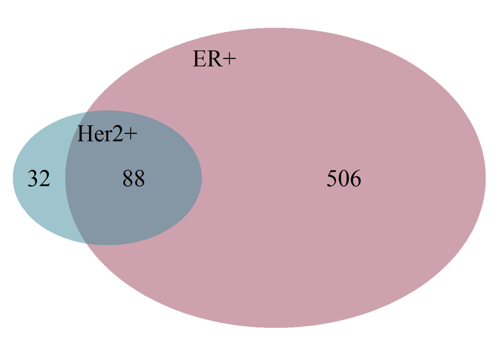

```r
# Now out of curiosity we want to know if there is a difference in age based on these attributes.

age.both = intersect (er_POS,her2p )
age.both=myclinicaldata[ myclinicaldata$pid %in% age.both, ]$AGE
age.Her2only.noER = setdiff( her2p, er_POS)
age.Her2only.noER = myclinicaldata[ myclinicaldata$pid %in% age.Her2only.noER, ]$AGE

temp = rbind (
data.frame ( age = age.both, type= rep("both", length(age.both)) )
,data.frame ( age = age.Her2only.noER, type= rep("Heronly", length(age.Her2only.noER)))
)

median ( age.Her2only.noER )
```

```
## [1] 57.5
```

```r
median ( age.both )
```

```
## [1] 61.5
```

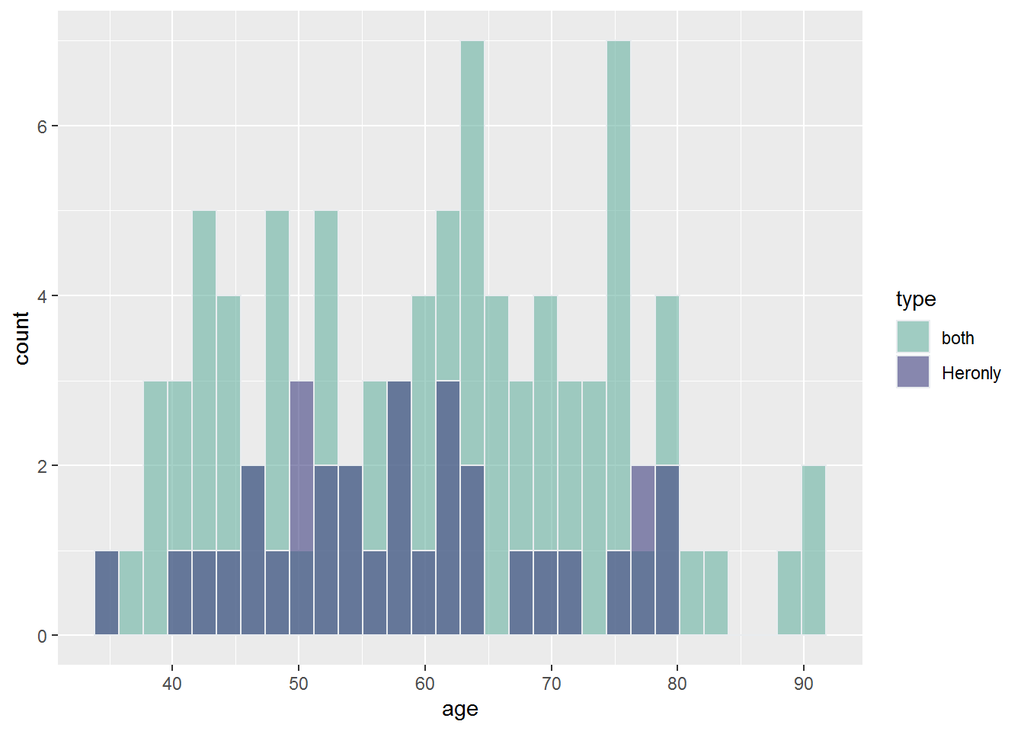

```r
ggplot( temp, aes(x=age, fill=type)) +
    geom_histogram( color="#e9ecef", alpha=0.6, position = 'identity') +
    scale_fill_manual(values=c("#69b3a2", "#404080"))
```

BONUS question to take home. As a pharmacologist how can you use DFS and OS? For example the histogram above only shows age of onset. However, question what if you hypothesize that having HER2 positive is much worse of survival then having both HER2 and ER+?

```r
# Now lets see what information is available for your study
mygeneticprofile = getGeneticProfiles(cbiop,brca.study)
k2 ( mygeneticprofile, "types of data available for chosen case" )
```

types of data available for chosen case

| genetic_profile_id | genetic_profile_name | genetic_profile_description | cancer_study_id | genetic_alteration_type | show_profile_in_analysis_tab |
| --- | --- | --- | --- | --- | --- |
| brca_tcga_pub2015_protein_quantification | Protein expression (RPPA) | Protein expression measured by reverse-phase protein array | 2119 | PROTEIN_LEVEL | false |
| brca_tcga_pub2015_gistic | Putative copy-number alterations from GISTIC | Putative copy-number calls on 1080 cases determined using GISTIC 2.0. Values: -2 = homozygous deletion; -1 = hemizygous deletion; 0 = neutral / no change; 1 = gain; 2 = high level amplification. | 2119 | COPY_NUMBER_ALTERATION | true |
| brca_tcga_pub2015_mrna | mRNA expression (microarray) | Expression levels for 17157 genes in 590 brca cases (Agilent microarray). | 2119 | MRNA_EXPRESSION | false |
| brca_tcga_pub2015_rna_seq_v2_mrna | mRNA expression (RNA Seq V2 RSEM) | mRNA gene expression (RNA Seq V2 RSEM) | 2119 | MRNA_EXPRESSION | false |
| brca_tcga_pub2015_linear_CNA | Relative linear copy-number values | Relative linear copy-number values for each gene (from Affymetrix SNP6). | 2119 | COPY_NUMBER_ALTERATION | false |
| brca_tcga_pub2015_methylation_hm27 | Methylation (HM27) | Methylation (HM27) beta-values for genes in 343 cases. For genes with multiple methylation probes, the probe most anti-correlated with expression. | 2119 | METHYLATION | false |
| brca_tcga_pub2015_methylation_hm450 | Methylation (HM450) | Methylation (HM450) beta-values for genes in 869 cases. For genes with multiple methylation probes, the probe most anti-correlated with expression. | 2119 | METHYLATION | false |
| brca_tcga_pub2015_mutations | Mutations | Mutation data from whole exome sequencing of 817 Breast Invasive Carcinoma tumor/normal pairs. | 2119 | MUTATION_EXTENDED | true |

```r
# so looking at that we now know it contains several interesting modalities.
# lets pick up 3 types of analysis that may be of interests

mutation = mygeneticprofile[grepl( "Mutation", mygeneticprofile$genetic_profile_name), ]$genetic_profile_id

# ? what other modalities do you think may be of interest
# anyone want to guess what "probe most anti-correlated with expression means"
cna = mygeneticprofile[grepl( "Putative copy", mygeneticprofile$genetic_profile_name),1 ]

exp = mygeneticprofile[grepl( "V2 RSEM", mygeneticprofile$genetic_profile_name),1 ]
```

# Now that we have a basic understanding of what is available lets go and download the actual data.

**Important** Due to the nature of the API and having so many people use it at once the connection might fail. If that is the case retry or if all else fails use the frozen version which has already been previosly downloaded.

```r
# lets collect this through a loop so not to overwhelm the system
# its important to be mindful of resources when mining data.  We need to play nice and consider the server load.
# ? what do you think we can do to miminize server load?

# For this class we are going to just download genes that are relevant to cancer.
# genes that had already been implicated in cancer.
# We do this by looking through different organization and cross reference a list of genes.

k2 ( cancer.list[17:25, ], "cancer list")
```

cancer list

|  | gene | custom | cosmic | clinvar.all.cancer | FM.combined | ucsf500v2 | civic | broad.target | msk.impact | umich.mioncoseq |
| --- | --- | --- | --- | --- | --- | --- | --- | --- | --- | --- |
| 17 | ABL1 |  | X | X | X | X | X | X | X | X |
| 18 | ABL2 |  | X |  | X | X |  |  |  | X |
| 19 | ABRAXAS1 |  |  | X |  |  |  |  | X |  |
| 20 | ACAN |  |  | X |  |  |  |  |  |  |
| 21 | ACKR3 |  | X |  |  |  |  |  |  |  |
| 22 | ACRV1 |  |  | X |  |  |  |  |  |  |
| 23 | ACSL3 |  | X |  |  |  |  |  |  |  |
| 24 | ACSL6 |  | X |  | X |  |  |  |  |  |
| 25 | ACTA1 |  |  |  |  |  | X |  |  |  |

```r
length ( cancer.gene)
```

```
## [1] 1805
```

```r
# lets check this list to make sure genes that are relevant to breast cancer exists

imp = as.character ( cancer.list[grepl("^BRCA|^ATM$|^BARD1$|^CDH1$|^CHEK2$|^NBN$|^NF1$|^PALB2$|^PTEN$", cancer.list$gene), ]$gene )

# ? why did we add ^ in front and $ for only some genes and not others?

k2 ( cancer.list[cancer.list$gene %in% imp, ], "breast cancer genes")
```

breast cancer genes

|  | gene | custom | cosmic | clinvar.all.cancer | FM.combined | ucsf500v2 | civic | broad.target | msk.impact | umich.mioncoseq |
| --- | --- | --- | --- | --- | --- | --- | --- | --- | --- | --- |
| 108 | ATM |  | X | X | X | X | X | X | X | X |
| 129 | BARD1 |  |  | X | X | X |  |  | X |  |
| 159 | BRCA1 |  | X | X | X | X | X | X | X |  |
| 160 | BRCA2 |  | X | X | X | X | X | X | X | X |
| 248 | CDH1 |  | X | X | X | X | X | X | X | X |
| 279 | CHEK2 |  | X | X | X | X | X |  | X |  |
| 1032 | NBN |  | X | X |  | X | X |  | X |  |
| 1052 | NF1 |  | X | X | X | X | X | X | X | X |
| 1128 | PALB2 |  | X | X | X | X | X |  | X | X |
| 1265 | PTEN |  | X | X | X | X | X | X | X | X |

```r
total = ceiling ( length( cancer.gene)/100  )  *100
mutations = data.frame (   stringsAsFactors = F )
expression = data.frame (   stringsAsFactors = F )
e = 1
for(i in seq(from=150, to=total, by=150)){

    if ( i > length(cancer.gene)){
        i = length(cancer.gene)
    }

    print ( paste ( e, i ))
    temp = getMutationData(cbiop , brca.study, mutation, cancer.gene[e:i])



    mutations = rbind ( mutations, temp)
    Sys.sleep (2) # lets give the system a break
        e2 = 1
        exp.temp2 = 1
        for(i2 in seq(from=150, to=length ( myclinicaldata$pid), by=150)){
        exp.temp = getProfileData(cbiop , cancer.gene[e:i]
                              , exp
                              , getCaseLists(cbiop,brca.study)[1,1] , myclinicaldata$pid[e2:i2])
        if ( exp.temp2 == 1){
            exp.temp2 =   t ( exp.temp)
        }else {
            exp.temp2 =  cbind ( exp.temp2,  t ( exp.temp))
        }
        e2 = i2+ 1
        Sys.sleep (1) # lets give the system a break
        }

    e = i + 1
    expression = rbind ( expression, exp.temp2)



}
```

```
## [1] "1 150"
## [1] "151 300"
## [1] "301 450"
## [1] "451 600"
## [1] "601 750"
## [1] "751 900"
## [1] "901 1050"
## [1] "1051 1200"
## [1] "1201 1350"
## [1] "1351 1500"
## [1] "1501 1650"
## [1] "1651 1800"
```

```r
# create coordinates
mutations$igv = paste ( mutations$chr, mutations$start_position, mutations$end_position, mutations$reference_allele, mutations$variant_allele)

# there is an error in the mutation table.  The links are obsolete.  Here we fix it.
# by replacing the older url with this: http://mutationassessor.org/r3

mutations$xvar_link = gsub('getma.org','http://mutationassessor.org/r3', mutations$xvar_link)
mutations$xvar_link_msa = gsub('getma.org','http://mutationassessor.org/r3', mutations$xvar_link_msa )
mutations$xvar_link_pdb = gsub('getma.org','http://mutationassessor.org/r3', mutations$xvar_link_pdb  )
```

Besides Mutation data we also downloaded expression RNAseq data in the form of TPM. * Let take a look at some of our favorite genes.

```r
expressionc= expression[complete.cases(expression), ]
samplesnice = gsub ( "-",".", samples)
expressionc[ row.names (expressionc ) %in% c(  "TP53" , "KRAS"), samplesnice ]
```

|  | TCGA.C8.A3M7.01 | TCGA.GM.A2D9.01 | TCGA.BH.A1FL.01 | TCGA.E2.A14Z.01 | TCGA.BH.A1FC.01 | TCGA.AC.A2QJ.01 | TCGA.EW.A1P8.01 | TCGA.E2.A1LE.01 | TCGA.E2.A1LK.01 | TCGA.AC.A2FE.01 |
| --- | --- | --- | --- | --- | --- | --- | --- | --- | --- | --- |
| KRAS | 1400.263 | 997.8308 | 1131.613 | 761.435 | 1579.1100 | 286.5531 | 2840.502 | 714.725 | 619.7783 | 1517.444 |
| TP53 | 1157.152 | 1956.6161 | 2613.977 | 2178.475 | 469.8786 | 413.3881 | 4563.082 | 2327.514 | 322.8012 | 2234.703 |

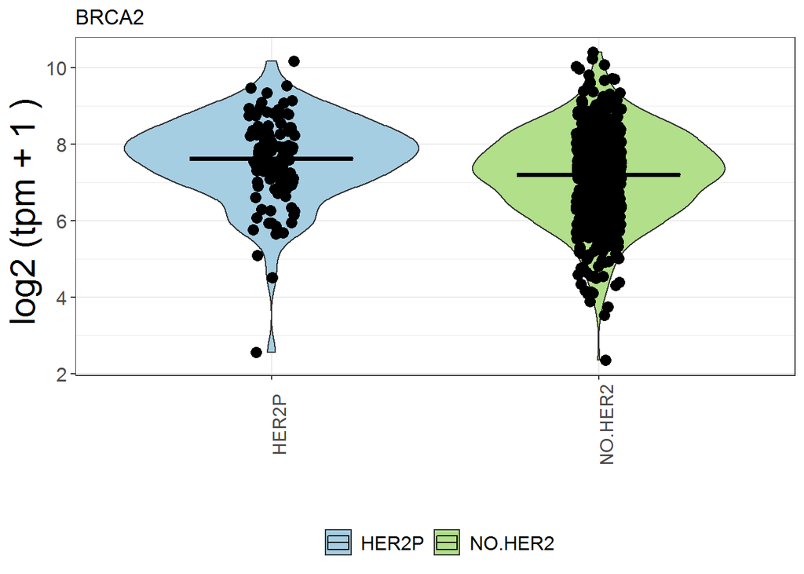

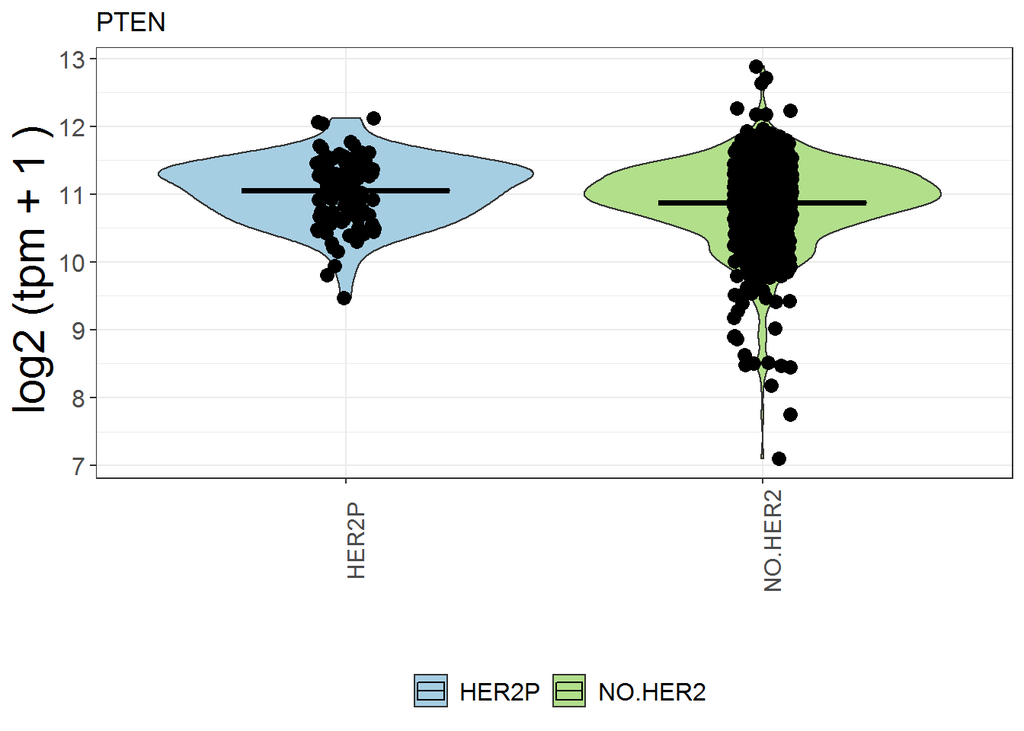

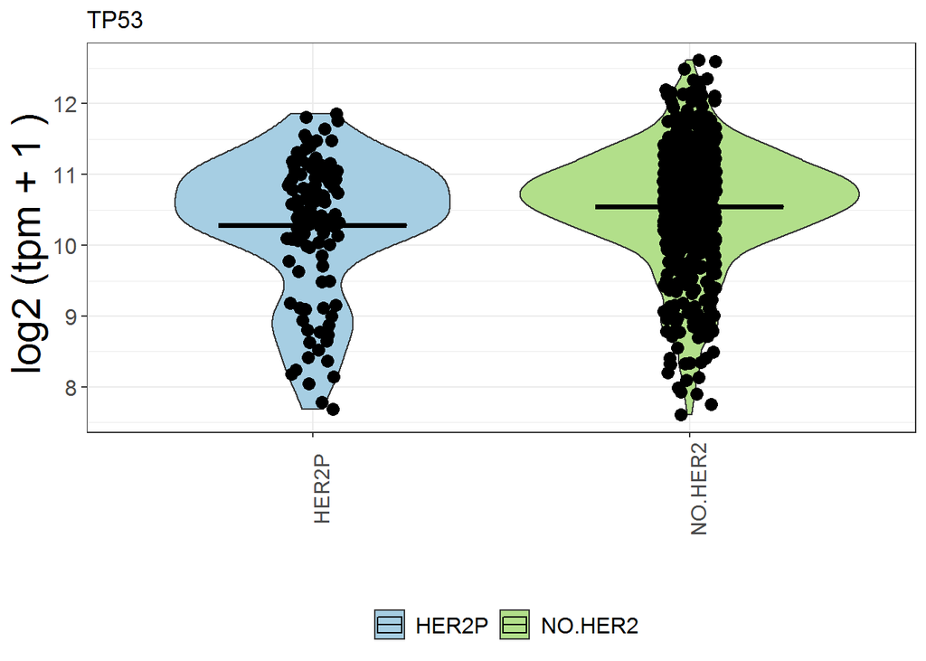

```r
for ( gene in c("BRCA2","PTEN","TP53")){

g1 = melt (  expression[gene,  ]  )
colnames ( g1 )= c("pid","value")
g1$pid = gsub ( "\\.","-", g1$pid)

g1$HER2p = ifelse ( g1$pid %in% her2p, "HER2P", "NO.HER2")
g1$value = log2 ( g1$value + 1 )

gthis = ggplot(g1, aes(y=value, x=HER2p, fill=HER2p)) +
        geom_violin()+
        geom_jitter(shape=19, position=position_jitter(0.07), size=3 ) +
        theme_bw() +
        ylab("log2 (tpm + 1 ) ") +
        xlab("") +
        theme(legend.position="bottom", legend.title=element_blank(), legend.key = element_blank(),

              axis.text.y = element_text(size=12),
              axis.text.x = element_text(angle = 90, size=11.5),
              axis.title.x = element_text(size=22),

              axis.title.y     = element_text(size=22),
              legend.text      =element_text(size=12)
        ) + stat_summary(fun.y = mean, fun.ymin = mean, fun.ymax = mean,
                         geom = "crossbar", width = .5)  + ggtitle ( gene ) +
    scale_fill_manual(values = c("#a6cee3","#b2df8a", "#fdbf6f") )
plot ( gthis )
}
```

# lets study the mutation table

```r
dim ( mutations )
```

```
## [1] 9045   23
```

```r
# lets take a few minutes here to go over the different fields.
names ( mutations )
```

```
##  [1] "entrez_gene_id"              "gene_symbol"
##  [3] "case_id"                     "sequencing_center"
##  [5] "mutation_status"             "mutation_type"
##  [7] "validation_status"           "amino_acid_change"
##  [9] "functional_impact_score"     "xvar_link"
## [11] "xvar_link_pdb"               "xvar_link_msa"
## [13] "chr"                         "start_position"
## [15] "end_position"                "reference_allele"
## [17] "variant_allele"              "reference_read_count_tumor"
## [19] "variant_read_count_tumor"    "reference_read_count_normal"
## [21] "variant_read_count_normal"   "genetic_profile_id"
## [23] "igv"
```

```r
unique( mutations$mutation_type)
```

```
## [1] "Missense_Mutation"      "Nonsense_Mutation"
## [3] "Splice_Site"            "Frame_Shift_Ins"
## [5] "Frame_Shift_Del"        "In_Frame_Del"
## [7] "In_Frame_Ins"           "Translation_Start_Site"
## [9] "Nonstop_Mutation"
```

```r
# ? based on the lecture previously can identify the different mutation_type
# ? based on the lecture previously can you figure out what each of these mean?
# for example which of these are nonsynonymous substitution?
# ? for druggability which one of these do you think its more likely to be useful

# ? can you guess what is functional_impact_score
k2 ( data.frame ( table ( mutations$functional_impact_score)  ), "impact scores " )
```

impact scores

| Var1 | Freq |
| --- | --- |
|  | 1578 |
| [Not Available] | 51 |
| H | 322 |
| L | 1986 |
| M | 1981 |
| N | 1263 |

```r
# make sure that your sample has mutations.
#? if you don't see any or obvious mutation where else can look at for the driver signal?

nrow ( mutations [ mutations$case_id ==  myid , ] )
```

```
## [1] 14
```

```r
# ? if you have more than one sample, say you want to check all 10 samples in the class, how would you do this?
# ? this is important, for example previously we were able to subset for Triple-negative breast tumors

samples
```

```
##  [1] "TCGA-C8-A3M7-01" "TCGA-GM-A2D9-01" "TCGA-BH-A1FL-01"
##  [4] "TCGA-E2-A14Z-01" "TCGA-BH-A1FC-01" "TCGA-AC-A2QJ-01"
##  [7] "TCGA-EW-A1P8-01" "TCGA-E2-A1LE-01" "TCGA-E2-A1LK-01"
## [10] "TCGA-AC-A2FE-01"
```

```r
final =  mutations [ mutations$case_id %in% samples, ]
unique ( final$case_id)
```

```
##  [1] "TCGA-C8-A3M7-01" "TCGA-E2-A1LK-01" "TCGA-EW-A1P8-01"
##  [4] "TCGA-BH-A1FC-01" "TCGA-GM-A2D9-01" "TCGA-E2-A14Z-01"
##  [7] "TCGA-BH-A1FL-01" "TCGA-E2-A1LE-01" "TCGA-AC-A2FE-01"
## [10] "TCGA-AC-A2QJ-01"
```

```r
# so as you can see above there are a total of 10 unique samples.

# lets clear up junk
gc()
```

```
##            used  (Mb) gc trigger  (Mb) max used  (Mb)
## Ncells  3597686 192.2    5369677 286.8  5369677 286.8
## Vcells 33020668 252.0   51079167 389.8 42499299 324.3
```

# Now lets talk a bit about how to identify pathogenic mutations.

- recall some of the things that were mentioned previously?

```r
# For example we can detect important mutations is to see if other resources are available.
# Here we use cosmic a manaully curated list of recurrent mutations in cancer and look for keyword breast

k2 ( head ( cosmic.70[ grepl("breast",  cosmic.70$description ), ] ), "breast cancer in cosmic")
```

[output not shown]

breast cancer in cosmic

```r
# lets integrate cosmic into our mutation table

mutations = merge ( mutations, cosmic.70, by="igv", all.x=T, all.y=F )

# ? note how we are merging by coordinates.  This is the most accurate way to do this.
# ? why do you think all.x = T and all.y=F

# let us find out how many mutations we have that is also found in cosmic
# the description field should not be empty if there was a cosmic entry

nrow ( mutations[ ! is.na ( mutations$description ),  ] ) / nrow (mutations)
```

```
## [1] 0.7338861
```

```r
# ? wow thats a huge ratio , why do think the ratio is so high?

# BONUS check if cosmic contain BRCA mutations.  This is a good sanity check.

k2 ( head ( mutations[ grepl("^BRCA", mutations$gene_symbol), c("amino_acid_change","chr.x","start_position","end_position","reference_allele", "variant_allele",
"gene_symbol","case_id","mutation_status","mutation_type","description")] ) )
```

[output not shown]

```r
# BONUS go to https://cancer.sanger.ac.uk/cosmic and compare this.
# ? does everything match why not?



# BONUS can you find all BRCA mutation that is Missense_Mutation AND found is cosmic in the mutation db?
# hint, mutations$mutation_type == "Missense_Mutation"
```

# Now that the data has been succesfully donwloaded lets study your breast cancer set.

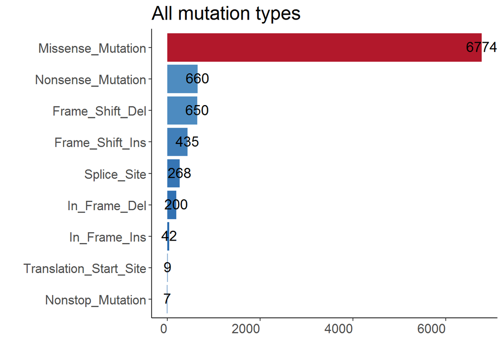

```r
# lets tabulate the types of mutations

mutation.type = data.frame ( table ( mutations$mutation_type))

mutation.type = mutation.type[ order ( mutation.type$Freq), ]

mutation.type$Var1 = factor ( mutation.type$Var1, levels = mutation.type$Var1)

ggplot(mutation.type, aes(Var1,Freq), label=Freq ) +
    geom_bar(aes(fill = Freq), stat="identity", position = "dodge") +
    coord_flip() +
    scale_fill_distiller(palette = "RdBu") + xlab("") + ylab("") +
    theme(strip.text.y = element_text(angle = 0), legend.position="none") +
    geom_text(aes(label=Freq), position=position_dodge(width=0.9), vjust=.4, hjust = .5, size=5) +
    theme(panel.grid.major = element_blank(),
          panel.grid.minor = element_blank(),
          panel.background = element_blank(),
          axis.line = element_line(colour = "black"),
          text = element_text(size=16),  # size of label
          axis.text.x = element_text(angle=0, hjust=1) ) + ggtitle ( "All mutation types")
```

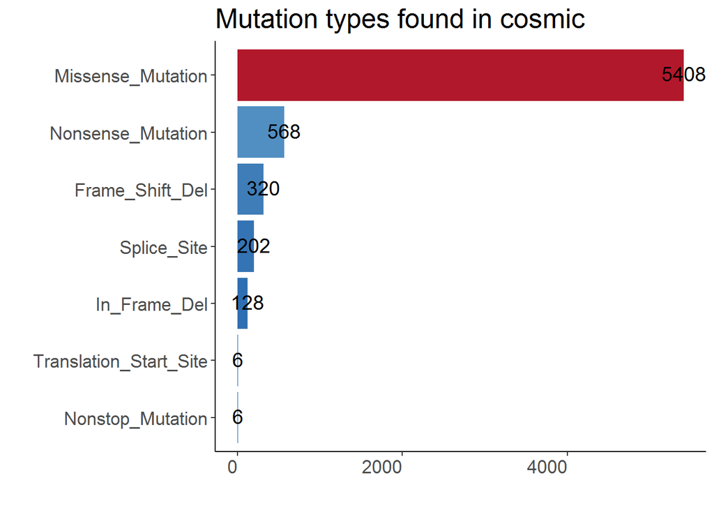

```r
# As mentioned previously one reliable way to look for relevant mutations is to match it against what has been previosly observed and/or study. Here we can try to use Cosmic however other organization may be relevant as well including clinvar

cosmic.mutation = mutations [ !is.na(mutations$description), ]

mutation.type = data.frame ( table ( cosmic.mutation$mutation_type))

mutation.type = mutation.type[ order ( mutation.type$Freq), ]
mutation.type$Var1 = factor ( mutation.type$Var1, levels = mutation.type$Var1)

ggplot(mutation.type, aes(Var1,Freq), label=Freq ) +
    geom_bar(aes(fill = Freq), stat="identity", position = "dodge") +
    coord_flip() +
    scale_fill_distiller(palette = "RdBu") + xlab("") + ylab("") +
    theme(strip.text.y = element_text(angle = 0), legend.position="none") +
    geom_text(aes(label=Freq), position=position_dodge(width=0.9), vjust=.4, hjust = .5, size=5) +
    theme(panel.grid.major = element_blank(),
          panel.grid.minor = element_blank(),
          panel.background = element_blank(),
          axis.line = element_line(colour = "black"),
          text = element_text(size=16),  # size of label
          axis.text.x = element_text(angle=0, hjust=1) ) + ggtitle ( "Mutation types found in cosmic")
```

```r
# ? seems like missense mutation is the most recurrent.  Can you think of any way to filter the data further

# ? in the lecture we talked about depth.  So lets calculate this.

mutations$dp = mutations$variant_read_count_tumor + mutations$reference_read_count_tumor
quantile ( mutations$dp)
```

```
##   0%  25%  50%  75% 100%
##    1   43   78  142 3354
```

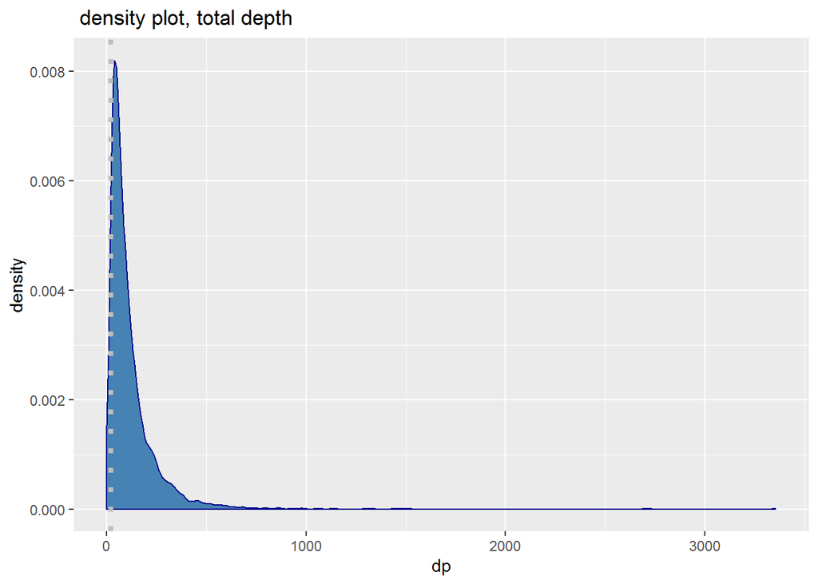

```r
 ggplot(mutations, aes(x=dp)) +
  geom_density( color="darkblue", fill="steelblue" ) + geom_vline(xintercept = 21, linetype="dotted",
                color = "grey", size=1.5) + ggtitle ( " density plot, total depth")
```

```r
# ? by looking at this plot and quantile we can see that there is a good amount of mutations that are under 21
# ? how would you remove this?

# before
dim ( mutations )
```

```
## [1] 9045   30
```

```r
# after
mutations = mutations[ mutations$dp > 21, ]
dim (mutations )
```

```
## [1] 8384   30
```

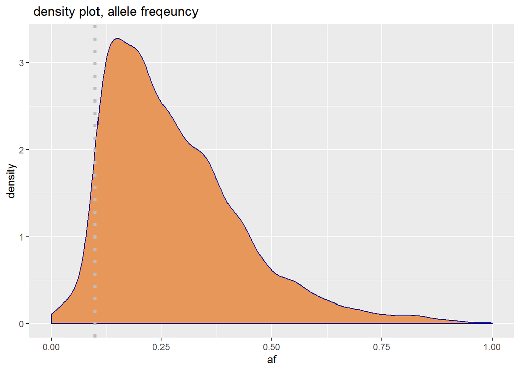

```r
# another thing we can look at is Allele frequency
# lets calculate allele freqeuncy here as well

mutations$af = mutations$variant_read_count_tumor / mutations$dp

 ggplot(mutations, aes(x=af)) +
  geom_density( color="darkblue", fill="#e8975a" ) + geom_vline(xintercept = .1, linetype="dotted",
                color = "grey", size=1.5) + ggtitle ( " density plot, allele freqeuncy")
```

```r
# ? what do you think it means when af is higher for a particular mutation
# Bonus pick the top 10 mutations ranked by af

mutations = mutations[ order ( - mutations$af ) , ]

# clean mut head
cleanmut = c ("igv","dp","af","gene_symbol","case_id",  "mutation_type", "amino_acid_change" , "functional_impact_score"
              , "variant_read_count_tumor"  ,"reference_read_count_tumor" , "description" )

k2 ( head ( mutations[ , cleanmut], 10) , "top 10 variant ranked by AF")
```

top 10 variant ranked by AF

|  | igv | dp | af | gene_symbol | case_id | mutation_type | amino_acid_change | functional_impact_score | variant_read_count_tumor | reference_read_count_tumor | description |
| --- | --- | --- | --- | --- | --- | --- | --- | --- | --- | --- | --- |
| 3129 | 16 67670628 67670628 G T | 29 | 1.0000000 | CTCF | TCGA-E2-A15T-01 | Nonsense_Mutation | E625* | NA | 29 | 0 | ID=COSM435539;OCCURENCE=1(breast) |
| 6157 | 3 178916876 178916876 G A | 3354 | 0.9821109 | PIK3CA | TCGA-A2-A04P-01 | Missense_Mutation | R88Q | M | 3294 | 60 | ID=COSM746,COSM271684;OCCURENCE=9(central_nervous_system),1(stomach),2(cervix),41(endometrium),24(large_intestine),3(urinary_tract),3(pancreas),3(breast) |
| 1657 | 11 75623074 75623074 C T | 504 | 0.9623016 | UVRAG | TCGA-A7-A4SB-01 | Missense_Mutation | S195F | M | 485 | 19 | ID=COSM3810443;OCCURENCE=1(breast) |
| 3882 | 17 7577097 7577097 C A | 67 | 0.9402985 | TP53 | TCGA-AC-A2QH-01 | Missense_Mutation | D281Y | M | 63 | 4 | ID=COSM11516,COSM214193,COSM3820706,COSM1646814;OCCURENCE=4(lung),2(haematopoietic_and_lymphoid_tissue),1(upper_aerodigestive_tract),2(breast),1(liver),1(kidney),1(endometrium) |
| 4100 | 17 7579311 7579311 C - | 28 | 0.9285714 | TP53 | TCGA-B6-A1KF-01 | Splice_Site | X125_splice | NA | 26 | 2 | ID=COSM318394,COSM318396,COSM318395;OCCURENCE=1(oesophagus),1(lung) |
| 8941 | 9 32543678 32543678 G A | 28 | 0.9285714 | TOPORS | TCGA-A8-A06Q-01 | Missense_Mutation | S282L | M | 26 | 2 | ID=COSM455823;OCCURENCE=1(breast) |
| 4087 | 17 7578532 7578532 A T | 41 | 0.9268293 | TP53 | TCGA-A1-A0SK-01 | Missense_Mutation | M133K | N | 38 | 3 | ID=COSM11781,COSM437606,COSM437605,COSM437608,COSM437607;OCCURENCE=1(prostate),1(pancreas),3(breast),2(oesophagus),2(stomach),3(haematopoietic_and_lymphoid_tissue) |
| 7169 | 5 180058776 180058776 G - | 205 | 0.9268293 | FLT4 | TCGA-AN-A0FX-01 | Frame_Shift_Del | L21Wfs*2 |  | 190 | 15 | NA |
| 1697 | 11 92507249 92507249 G T | 286 | 0.9125874 | FAT3 | TCGA-E9-A1N8-01 | Missense_Mutation | G1413V | H | 261 | 25 | ID=COSM1475968,COSM1475969;OCCURENCE=1(breast) |
| 3906 | 17 7577121 7577121 G A | 22 | 0.9090909 | TP53 | TCGA-EW-A1PC-01 | Missense_Mutation | R273C | M | 20 | 2 | ID=COSM3355991,COSM10659,COSM1645518,COSM99933;OCCURENCE=34(ovary),14(endometrium),3(small_intestine),22(breast),11(skin),5(prostate),111(large_intestine),3(biliary_tract),1(genital_tract),1(adrenal_g… |

```r
# lets further filter the mutations with any af > .1
mutations = mutations[ mutations$af > .1, ]
dim (mutations)
```

```
## [1] 8026   31
```

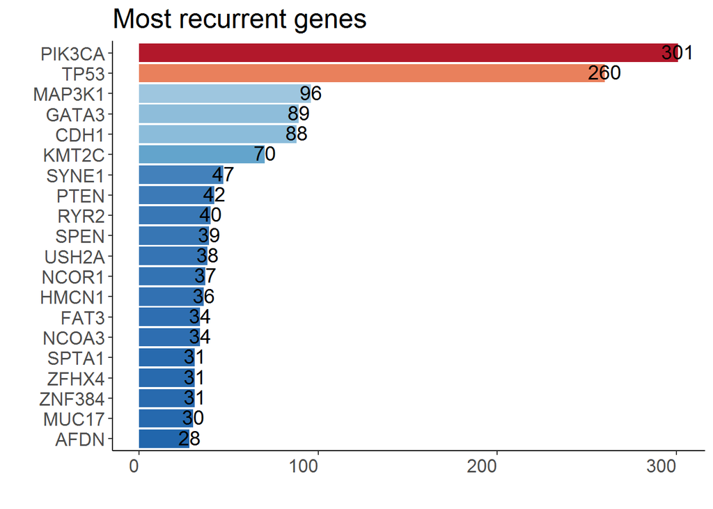

```r
# plot 20 highest recurrent gene mutations

mutation.gene = data.frame ( table ( mutations$gene_symbol))

mutation.gene = mutation.gene[ order ( - mutation.gene$Freq), ]
mutation.gene$Var1 = factor ( mutation.gene$Var1, levels = rev ( mutation.gene$Var1) )

ggplot(mutation.gene [ 1:20, ] , aes(Var1,Freq), label=Freq ) +
    geom_bar(aes(fill = Freq), stat="identity", position = "dodge") +
    coord_flip() +
    scale_fill_distiller(palette = "RdBu") + xlab("") + ylab("") +
    theme(strip.text.y = element_text(angle = 0), legend.position="none") +
    geom_text(aes(label=Freq), position=position_dodge(width=0.9), vjust=.4, hjust = .5, size=5) +
    theme(panel.grid.major = element_blank(),
          panel.grid.minor = element_blank(),
          panel.background = element_blank(),
          axis.line = element_line(colour = "black"),
          text = element_text(size=16),  # size of label
          axis.text.x = element_text(angle=0, hjust=1) ) + ggtitle ( "Most recurrent genes")
```

```r
# based on literature these are some of the genes involved in breast cancer.
imp
```

```
##  [1] "ATM"   "BARD1" "BRCA1" "BRCA2" "CDH1"  "CHEK2" "NBN"   "NF1"
##  [9] "PALB2" "PTEN"
```

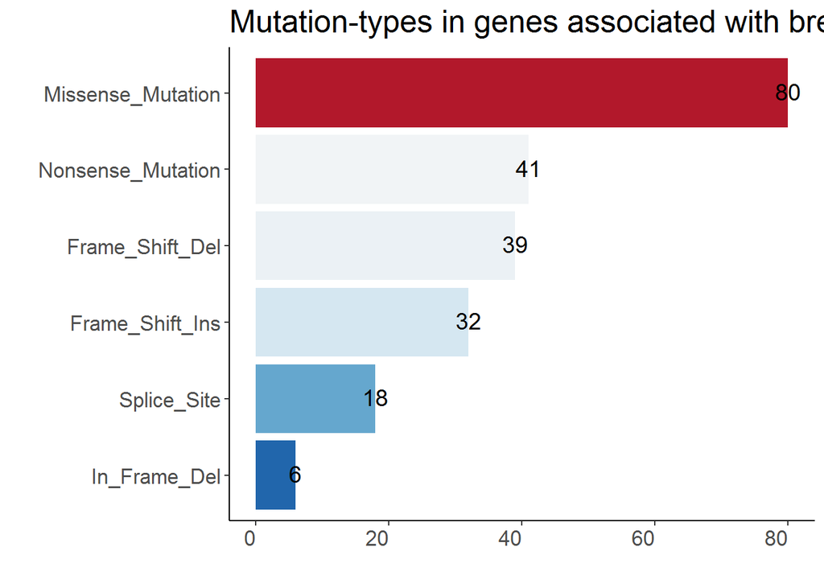

```r
# lets study them and see what types of mutations corresponds most with these genes.

mutation.brca = data.frame ( table ( mutations[ mutations$gene_symbol %in% imp, ] $mutation_type))

mutation.brca = mutation.brca[ order ( mutation.brca$Freq), ]
mutation.brca$Var1 = factor ( mutation.brca$Var1, levels = mutation.brca$Var1)

ggplot(mutation.brca, aes(Var1,Freq), label=Freq ) +
    geom_bar(aes(fill = Freq), stat="identity", position = "dodge") +
    coord_flip() +
    scale_fill_distiller(palette = "RdBu") + xlab("") + ylab("") +
    theme(strip.text.y = element_text(angle = 0), legend.position="none") +
    geom_text(aes(label=Freq), position=position_dodge(width=0.9), vjust=.4, hjust = .5, size=5) +
    theme(panel.grid.major = element_blank(),
          panel.grid.minor = element_blank(),
          panel.background = element_blank(),
          axis.line = element_line(colour = "black"),
          text = element_text(size=16),  # size of label
          axis.text.x = element_text(angle=0, hjust=1) ) + ggtitle ( "Mutation-types in genes associated with breast cancer")
```

```r
# lets assume that we don't know these genes
# BONUS can you think of another way to rediscover these genes and/or find novel ones?

# HERE you is where the fun is! The discovery part.  And there are many many ways to do this.
# so be creative!

# here is a 2 sec way to do this.
# simply look in cosmic to see how often these genes appears in breast cancer.
imp.brac = data.frame ( table ( mutations[ grepl( "breast", mutations$description), ]$gene_symbol ) )
imp.brac$fraction = imp.brac$Freq / nrow ( mutations)
imp.brac = imp.brac [ order ( -imp.brac$fraction) , ]

k2 ( head ( imp.brac, 10), "top cosmic genes found in breast cancer")
```

top cosmic genes found in breast cancer

|  | Var1 | Freq | fraction |
| --- | --- | --- | --- |
| 899 | PIK3CA | 294 | 0.0366309 |
| 1234 | TP53 | 239 | 0.0297782 |
| 695 | MAP3K1 | 60 | 0.0074757 |
| 199 | CDH1 | 46 | 0.0057314 |
| 633 | KMT2C | 42 | 0.0052330 |
| 1183 | SYNE1 | 39 | 0.0048592 |
| 1058 | RYR2 | 38 | 0.0047346 |
| 1279 | USH2A | 34 | 0.0042362 |
| 470 | GATA3 | 32 | 0.0039870 |
| 786 | NCOR1 | 29 | 0.0036133 |

```r
# ? how does this compare to our plot above
# both analysis seem to show a lot of overlap eg that TP53 and PIK3CA are important.  Lets breakdown the mutation type a bit more for the top 5

top5 = as.character ( imp.brac$Var1[1:5] )
top5 = mutations[ mutations$gene_symbol %in% top5, ]$amino_acid_change
top5 = data.frame ( table ( top5 ) )
top5 = top5 [ order ( - top5$Freq), ]

# quick hack to add url, will not work with *

top5$url = paste0(url,top5$top5)
k2 ( head ( top5, 20), "top 20 recurrent mutations")
```

top 20 recurrent mutations

|  | top5 | Freq | url |
| --- | --- | --- | --- |
| 134 | H1047R | 109 | https://search.vumc.org/?query=H1047R |
| 94 | E545K | 53 | https://search.vumc.org/?query=E545K |
| 92 | E542K | 29 | https://search.vumc.org/?query=E542K |
| 234 | N345K | 12 | https://search.vumc.org/?query=N345K |
| 311 | R175H | 12 | https://search.vumc.org/?query=R175H |
| 133 | H1047L | 11 | https://search.vumc.org/?query=H1047L |
| 318 | R273H | 9 | https://search.vumc.org/?query=R273H |
| 102 | E726K | 8 | https://search.vumc.org/?query=E726K |
| 312 | R196* | 8 | https://search.vumc.org/?query=R196* |
| 143 | H193R | 6 | https://search.vumc.org/?query=H193R |
| 297 | Q546R | 6 | https://search.vumc.org/?query=Q546R |
| 316 | R248W | 6 | https://search.vumc.org/?query=R248W |
| 314 | R213* | 5 | https://search.vumc.org/?query=R213* |
| 22 | C176F | 4 | https://search.vumc.org/?query=C176F |
| 31 | C420R | 4 | https://search.vumc.org/?query=C420R |
| 87 | E453K | 4 | https://search.vumc.org/?query=E453K |
| 156 | I195T | 4 | https://search.vumc.org/?query=I195T |
| 242 | P127Afs*41 | 4 | https://search.vumc.org/?query=P127Afs*41 |
| 317 | R273C | 4 | https://search.vumc.org/?query=R273C |
| 331 | R342* | 4 | https://search.vumc.org/?query=R342* |

```r
# take the first mutation and google it what does it say?
# take the second, what does google say?



# part of studying mutations is look for clinical significance.  One way to do this is to match your mutations to actionable
# targets


mutations$drug = paste ( mutations$gene_symbol, mutations$amino_acid_change)

action = drug[ drug$match %in% unique ( mutations$drug  ), ]
action.f = c("gene" ,"variant" , "disease", "drugs", "evidence_type",
             "clinical_significance", "evidence_statement", "evidence_civic_url", "gene_civic_url" , "match"
)
k2 ( head ( action[ ,action.f], 20) ,"example of actionable mutations in the BRCA set" )
```

example of actionable mutations in the BRCA set

|  | gene | variant | disease | drugs | evidence_type | clinical_significance | evidence_statement | evidence_civic_url | gene_civic_url | match |
| --- | --- | --- | --- | --- | --- | --- | --- | --- | --- | --- |
| 73 | PIK3CA | E542K | Colorectal Cancer | Regorafenib | Predictive | N/A | PIK3CA mutation status was not predictive of response to regorafenib treatment in patients that had received standard therapy and progressed within 3 months of their last treatment. | https://civic.genome.wustl.edu/links/evidence_items/83 | https://civic.genome.wustl.edu/links/genes/37 | PIK3CA E542K |
| 120 | KRAS | G12V | Colorectal Cancer | Cetuximab | Predictive | Resistance | Cells harboring KRAS G12V mutation were insensitive to cetuximab treatment in isogenic SW48 cells and in a mouse xenograft model. | https://civic.genome.wustl.edu/links/evidence_items/136 | https://civic.genome.wustl.edu/links/genes/30 | KRAS G12V |
| 197 | IDH1 | R132C | Acute Myeloid Leukemia | NA | Diagnostic | Positive | IDH1 R132 mutation is associated with patients of older age, high platelet count during diagnosis, cytogenic normalcy and NPM1 mutation. | https://civic.genome.wustl.edu/links/evidence_items/224 | https://civic.genome.wustl.edu/links/genes/26 | IDH1 R132C |
| 199 | KRAS | G12C | Lung Cancer | NA | Diagnostic | Positive | KRAS G12C occur more frequently in women than men. | https://civic.genome.wustl.edu/links/evidence_items/227 | https://civic.genome.wustl.edu/links/genes/30 | KRAS G12C |
| 200 | KRAS | G12D | Lung Cancer | NA | Diagnostic | Positive | KRAS G12D mutation occurs in never smokers significantly more often than in smokers. | https://civic.genome.wustl.edu/links/evidence_items/228 | https://civic.genome.wustl.edu/links/genes/30 | KRAS G12D |
| 202 | AKT1 | E17K | Breast Cancer | MK-2206 | Predictive | Sensitivity/Response | Breast cancer cell lines with the AKT1 E17K mutation did not show sensitivity to AKT inhibitor MK-2206, unlike cell lines with PIK3CA mutations. | https://civic.genome.wustl.edu/links/evidence_items/231 | https://civic.genome.wustl.edu/links/genes/2 | AKT1 E17K |
| 212 | ERBB2 | L755S | Breast Cancer | Lapatinib | Predictive | Resistance | The L755S mutation was shown to confer resistance to lapatinib in MCF10A cell lines retrovirally transduced with wildtype or mutant ERBB2. | https://civic.genome.wustl.edu/links/evidence_items/241 | https://civic.genome.wustl.edu/links/genes/20 | ERBB2 L755S |
| 223 | PIK3CA | E542K | Colorectal Cancer | Cetuximab,Panitumumab | Predictive | Resistance | The presence of a PIK3CA mutation in exon 9 (such as E542K) or exon 20 were associated with lack of panitumumab or cetuximab response. | https://civic.genome.wustl.edu/links/evidence_items/256 | https://civic.genome.wustl.edu/links/genes/37 | PIK3CA E542K |
| 224 | PIK3CA | H1047R | Colorectal Cancer | Cetuximab,Panitumumab | Predictive | Resistance | In this study, a large cohort of metastatic colorectal cancer patients were treated with anti-epidermal growth factor receptor monoclonal antibodies (cetuximab or panitumumab). KRAS PIK3CA and PTEN we… | https://civic.genome.wustl.edu/links/evidence_items/258 | https://civic.genome.wustl.edu/links/genes/37 | PIK3CA H1047R |
| 244 | ERBB2 | D769H | Breast Cancer | Lapatinib,Neratinib | Predictive | Sensitivity/Response | In MCF10A cell lines, the D769H mutation was shown to be sensitive to neratinib. | https://civic.genome.wustl.edu/links/evidence_items/279 | https://civic.genome.wustl.edu/links/genes/20 | ERBB2 D769H |
| 245 | ERBB2 | D769Y | Breast Cancer | Neratinib | Predictive | Sensitivity/Response | In MCF10A cell lines, the D769Y mutation was shown to be sensitive to neratinib. | https://civic.genome.wustl.edu/links/evidence_items/280 | https://civic.genome.wustl.edu/links/genes/20 | ERBB2 D769Y |
| 247 | ERBB2 | G309A | Breast Cancer | Neratinib | Predictive | Sensitivity/Response | In MCF10A cell lines, the G309A mutation was shown to be sensitive to neratinib. | https://civic.genome.wustl.edu/links/evidence_items/282 | https://civic.genome.wustl.edu/links/genes/20 | ERBB2 G309A |
| 248 | ERBB2 | L755S | Breast Cancer | Neratinib | Predictive | Sensitivity/Response | The L755S mutation showed mild response to neratinib in MCF10A cell lines retrovirally transduced with wildtype or mutant ERBB2. | https://civic.genome.wustl.edu/links/evidence_items/283 | https://civic.genome.wustl.edu/links/genes/20 | ERBB2 L755S |
| 251 | ERBB2 | R678Q | Breast Cancer | Neratinib,Lapatinib | Predictive | Sensitivity/Response | MCF10A cells transduced with ERBB2 harboring an R678Q mutation were sensitive to lapatinib and the irreversible kinase inhibitor neratinib in an matrigel colony forming assay. | https://civic.genome.wustl.edu/links/evidence_items/286 | https://civic.genome.wustl.edu/links/genes/20 | ERBB2 R678Q |
| 253 | ERBB2 | V777L | Breast Cancer | Neratinib | Predictive | Sensitivity/Response | In MCF10A cell lines, the V777L mutation was shown to be sensitive to neratinib. | https://civic.genome.wustl.edu/links/evidence_items/288 | https://civic.genome.wustl.edu/links/genes/20 | ERBB2 V777L |
| 254 | ERBB2 | V842I | Breast Cancer | Neratinib | Predictive | Sensitivity/Response | In MCF10A cell lines, the V842I mutation was shown to be sensitive to neratinib. | https://civic.genome.wustl.edu/links/evidence_items/289 | https://civic.genome.wustl.edu/links/genes/20 | ERBB2 V842I |
| 269 | KRAS | G12D | Non-small Cell Lung Carcinoma | BEZ235 (NVP-BEZ235, Dactolisib),ARRY-142886 | Predictive | Sensitivity/Response | The use of NVP-BEZ235 in conjunction with ARRY-142886, but not as monotherapy, in a lung cancer model with KRAS G12D mutation led to marked tumor regression. | https://civic.genome.wustl.edu/links/evidence_items/305 | https://civic.genome.wustl.edu/links/genes/30 | KRAS G12D |
| 274 | PIK3CA | E542K | Breast Cancer | CH5132799 | Predictive | Sensitivity/Response | Breast cancer cell lines with E542K/E545K mutations showed increased sensitivity to CH5132799 than cells with wild-type PIK3CA gene. | https://civic.genome.wustl.edu/links/evidence_items/310 | https://civic.genome.wustl.edu/links/genes/37 | PIK3CA E542K |
| 275 | PIK3CA | E542K | Breast Cancer | Rapamycin (Sirolimus) | Predictive | Sensitivity/Response | Rapamycin inhibits transformation induced by mutation in PIK3CA. | https://civic.genome.wustl.edu/links/evidence_items/311 | https://civic.genome.wustl.edu/links/genes/37 | PIK3CA E542K |
| 276 | PIK3CA | H1047R | Breast Cancer | CH5132799 | Predictive | Sensitivity/Response | Breast cancer cell lines with H1047R mutation showed increased sensitivity to CH5132799 than cells with wild-type PIK3CA gene. | https://civic.genome.wustl.edu/links/evidence_items/314 | https://civic.genome.wustl.edu/links/genes/37 | PIK3CA H1047R |

```r
# Bonus can you figure out which samples have druggable targets?
#? look at evidence type. Can yo figure out which of these are diagnostic vs targetable?

k2 ( head ( action[action$clinical_significance == "Sensitivity/Response" ,action.f], 20) )
```

|  | gene | variant | disease | drugs | evidence_type | clinical_significance | evidence_statement | evidence_civic_url | gene_civic_url | match |
| --- | --- | --- | --- | --- | --- | --- | --- | --- | --- | --- |
| 202 | AKT1 | E17K | Breast Cancer | MK-2206 | Predictive | Sensitivity/Response | Breast cancer cell lines with the AKT1 E17K mutation did not show sensitivity to AKT inhibitor MK-2206, unlike cell lines with PIK3CA mutations. | https://civic.genome.wustl.edu/links/evidence_items/231 | https://civic.genome.wustl.edu/links/genes/2 | AKT1 E17K |
| 244 | ERBB2 | D769H | Breast Cancer | Lapatinib,Neratinib | Predictive | Sensitivity/Response | In MCF10A cell lines, the D769H mutation was shown to be sensitive to neratinib. | https://civic.genome.wustl.edu/links/evidence_items/279 | https://civic.genome.wustl.edu/links/genes/20 | ERBB2 D769H |
| 245 | ERBB2 | D769Y | Breast Cancer | Neratinib | Predictive | Sensitivity/Response | In MCF10A cell lines, the D769Y mutation was shown to be sensitive to neratinib. | https://civic.genome.wustl.edu/links/evidence_items/280 | https://civic.genome.wustl.edu/links/genes/20 | ERBB2 D769Y |
| 247 | ERBB2 | G309A | Breast Cancer | Neratinib | Predictive | Sensitivity/Response | In MCF10A cell lines, the G309A mutation was shown to be sensitive to neratinib. | https://civic.genome.wustl.edu/links/evidence_items/282 | https://civic.genome.wustl.edu/links/genes/20 | ERBB2 G309A |
| 248 | ERBB2 | L755S | Breast Cancer | Neratinib | Predictive | Sensitivity/Response | The L755S mutation showed mild response to neratinib in MCF10A cell lines retrovirally transduced with wildtype or mutant ERBB2. | https://civic.genome.wustl.edu/links/evidence_items/283 | https://civic.genome.wustl.edu/links/genes/20 | ERBB2 L755S |
| 251 | ERBB2 | R678Q | Breast Cancer | Neratinib,Lapatinib | Predictive | Sensitivity/Response | MCF10A cells transduced with ERBB2 harboring an R678Q mutation were sensitive to lapatinib and the irreversible kinase inhibitor neratinib in an matrigel colony forming assay. | https://civic.genome.wustl.edu/links/evidence_items/286 | https://civic.genome.wustl.edu/links/genes/20 | ERBB2 R678Q |
| 253 | ERBB2 | V777L | Breast Cancer | Neratinib | Predictive | Sensitivity/Response | In MCF10A cell lines, the V777L mutation was shown to be sensitive to neratinib. | https://civic.genome.wustl.edu/links/evidence_items/288 | https://civic.genome.wustl.edu/links/genes/20 | ERBB2 V777L |
| 254 | ERBB2 | V842I | Breast Cancer | Neratinib | Predictive | Sensitivity/Response | In MCF10A cell lines, the V842I mutation was shown to be sensitive to neratinib. | https://civic.genome.wustl.edu/links/evidence_items/289 | https://civic.genome.wustl.edu/links/genes/20 | ERBB2 V842I |
| 269 | KRAS | G12D | Non-small Cell Lung Carcinoma | BEZ235 (NVP-BEZ235, Dactolisib),ARRY-142886 | Predictive | Sensitivity/Response | The use of NVP-BEZ235 in conjunction with ARRY-142886, but not as monotherapy, in a lung cancer model with KRAS G12D mutation led to marked tumor regression. | https://civic.genome.wustl.edu/links/evidence_items/305 | https://civic.genome.wustl.edu/links/genes/30 | KRAS G12D |
| 274 | PIK3CA | E542K | Breast Cancer | CH5132799 | Predictive | Sensitivity/Response | Breast cancer cell lines with E542K/E545K mutations showed increased sensitivity to CH5132799 than cells with wild-type PIK3CA gene. | https://civic.genome.wustl.edu/links/evidence_items/310 | https://civic.genome.wustl.edu/links/genes/37 | PIK3CA E542K |
| 275 | PIK3CA | E542K | Breast Cancer | Rapamycin (Sirolimus) | Predictive | Sensitivity/Response | Rapamycin inhibits transformation induced by mutation in PIK3CA. | https://civic.genome.wustl.edu/links/evidence_items/311 | https://civic.genome.wustl.edu/links/genes/37 | PIK3CA E542K |
| 276 | PIK3CA | H1047R | Breast Cancer | CH5132799 | Predictive | Sensitivity/Response | Breast cancer cell lines with H1047R mutation showed increased sensitivity to CH5132799 than cells with wild-type PIK3CA gene. | https://civic.genome.wustl.edu/links/evidence_items/314 | https://civic.genome.wustl.edu/links/genes/37 | PIK3CA H1047R |
| 279 | TP53 | R175H | Breast Cancer | Doxorubicin | Predictive | Sensitivity/Response | Breast tumors in a mouse model with R172H mutation (homologous to human R175H) are more responsive to doxorubicin than breast tumors with wild type TP53. | https://civic.genome.wustl.edu/links/evidence_items/319 | https://civic.genome.wustl.edu/links/genes/45 | TP53 R175H |
| 552 | AKT1 | E17K | Melanoma | GSK2141795 | Predictive | Sensitivity/Response | A cell line with AKT E17K mutation was found to be sensitive to AKT inhibition with GSK2141795B in this study. | https://civic.genome.wustl.edu/links/evidence_items/707 | https://civic.genome.wustl.edu/links/genes/2 | AKT1 E17K |
| 554 | AKT1 | E17K | Breast Cancer | AZD5363 | Predictive | Sensitivity/Response | In a phase-I study of AZD5363, partial response was observed in 2 patients with breast and ovarian carcinoma, respectively, and AKT1 E17K mutations. While full study results have not yet been publishe… | https://civic.genome.wustl.edu/links/evidence_items/709 | https://civic.genome.wustl.edu/links/genes/2 | AKT1 E17K |
| 555 | PIK3CA | E545K | Breast Cancer | MK-2206,Pictilisib | Predictive | Sensitivity/Response | PIK3CA E545K mutation increased sensitivity to AKT inhibitor MK-2206 and PI3K inhibitor GDC-0941 in a breast cancer cell line model. | https://civic.genome.wustl.edu/links/evidence_items/710 | https://civic.genome.wustl.edu/links/genes/37 | PIK3CA E545K |
| 576 | IDH1 | R132C | Acute Myeloid Leukemia | GSK321 | Predictive | Sensitivity/Response | Newly developed allosteric inhibitors (GSK321) of IDH1 led to granulocytic differentiation in-vitro and in-vivo. | https://civic.genome.wustl.edu/links/evidence_items/732 | https://civic.genome.wustl.edu/links/genes/26 | IDH1 R132C |
| 636 | KRAS | G12V | Non-small Cell Lung Carcinoma | PD0332991 | Predictive | Sensitivity/Response | In vivo studies confirmed the activity of PD0332991 (CDK4 inhibitor) on KRAS G12V mutant tumors. 17% (2/12) of mice treated with PD0332991 developed detectable lesions, whereas 75% of mice (3/4) treat… | https://civic.genome.wustl.edu/links/evidence_items/795 | https://civic.genome.wustl.edu/links/genes/30 | KRAS G12V |
| 773 | KRAS | G12D | Pancreatic Carcinoma | MK-2206 | Predictive | Sensitivity/Response | Among 33 patients treated with pan-AKT inhibitor MK-2206 in this phase 1 study, one patient with pancreatic adenocarcinoma and PTEN loss and a KRAS G12D mutation experienced a decrease of approximatel… | https://civic.genome.wustl.edu/links/evidence_items/937 | https://civic.genome.wustl.edu/links/genes/30 | KRAS G12D |
| 970 | KRAS | G12C | Non-small Cell Lung Carcinoma | Docetaxel,Selumetinib (AZD6244) | Predictive | Sensitivity/Response | 83 patients from a phase II trial (docetaxel + placebo or MEK1/2 inhibitor selumetinib) with KRAS mutant tumors were retrospectively assessed for differences in OS, PFS, ORR and change in tumor size a… | https://civic.genome.wustl.edu/links/evidence_items/1142 | https://civic.genome.wustl.edu/links/genes/30 | KRAS G12C |

# HW at this point please use your own TCGA ID, study it using what you learn above. Assess QC on your sample, study what genes are most common and which if any are targetable.

```r
# here is example where I chose, myid = "TCGA-C8-A131-01"


actionid = drug[ drug$match %in% unique ( mutations[mutations$case_id == myid, ]  $drug  ), ]

actionid = actionid %>% dplyr::group_by(variant) %>%
        dplyr::summarise(
            gene = paste(unique ( gene ), collapse = "," ) ,
            disease = paste(unique ( disease ), collapse = "," ),
            clinical_significance =  paste(unique ( clinical_significance ), collapse = "," ),
            drugs = paste(unique ( drugs ), collapse = "," )

        ) %>%
        data.frame()

k2( actionid, myid)
```

TCGA-C8-A131-01

| variant | gene | disease | clinical_significance | drugs |
| --- | --- | --- | --- | --- |
| G12V | KRAS | Colorectal Cancer,Non-small Cell Lung Carcinoma,Cancer,Lung Cancer | Resistance,Sensitivity/Response,Poor Outcome | Cetuximab,PD0332991,NA,Docetaxel,Selumetinib (AZD6244),Crizotinib,Selumetinib (AZD6244),BEZ235,Panitumumab,Gefitinib,Regorafenib,Panitumumab,Cetuximab |
| H1047R | PIK3CA | Colorectal Cancer,Breast Cancer,Head And Neck Cancer,Lung Adenocarcinoma,Head And Neck Squamous Cell Carcinoma,Her2-receptor Positive Breast Cancer,Thyroid Cancer,Non-small Cell Lung Carcinoma | Resistance,Sensitivity/Response | Cetuximab,Panitumumab,CH5132799,Panitumumab,Cetuximab,BEZ235 (NVP-BEZ235, Dactolisib),Cetuximab,BEZ235 (NVP-BEZ235, Dactolisib),BYL719 (Alpelisib),Taselisib (GDC-0032),AZD5363,Trastuzumab,AZD5363,Lapa… |
| R175H | TP53 | Breast Cancer,Stomach Carcinoma,Cancer | Sensitivity/Response,Poor Outcome,Resistance | Doxorubicin,NA,EAP Protocol,AMGMDS3 |